# Chapter 2: Multiple Regression with Continuous Regressors

Statistical Modelling Methods: A Guide for the Social and Behavioural Sciences (2nd ed.)

Author

David Flora & Miranda Too

# Chapter 2 Textbook Content

Much of the material in this document builds on the R syntax and output for Chapter 1. If necessary, refer back to that document for reminders.

## Importing Movie Data

```r
#Import movie data and save as a data frame object called "movie.profits"
movie.profits <- read.table("movie.txt", header = T)

#We'll create a new data frame object for our analysis and give it the name "movie"
movie <- movie.profits

#Rename score to review
movie$review <- movie$score

movie$score <- NULL
```

# Multiple Linear Regression

## Research Example

### Figure 2.1 R Code - Scatterplots

As a first step we can visualize the bivariate relationships between these variables using scatterplots.

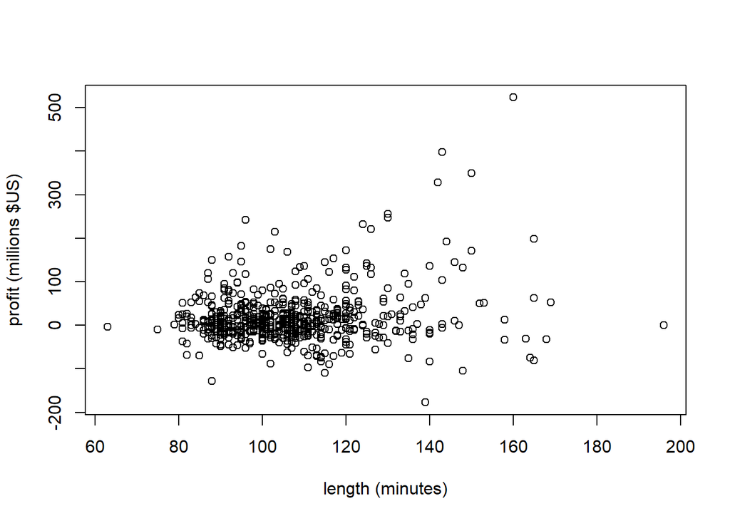

```r
#Scatterplot of profit by length
plot(profit ~ leng, data=movie,
            col="black", xlab="length (minutes)",
            ylab="profit (millions $US)")
```

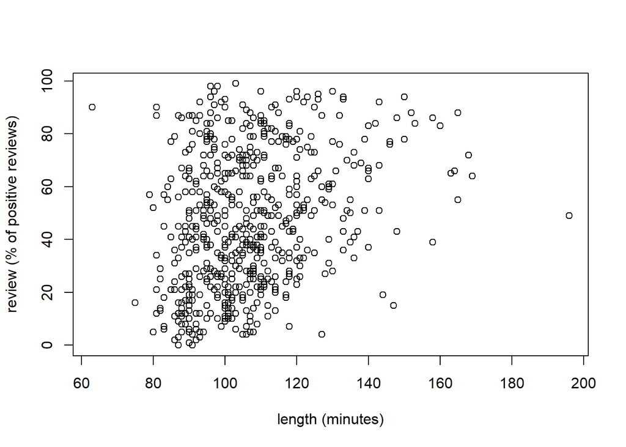

```r
#Scatterplot of review by length.
plot(review ~ leng, data=movie,
            col="black",  xlab="length (minutes)",
            ylab="review (% of positive reviews)")
```

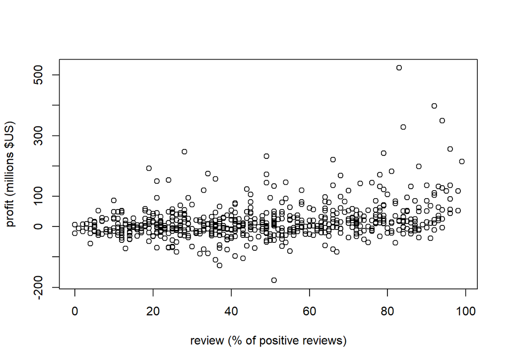

```r
#Scatterplot of profit by review (Figure 1.2, presented in Chapter 1)
plot(movie$profit ~ movie$review, xlab="review (% of positive reviews)",
     ylab="profit (millions $US)")
```

### Correlations

We can obtain Pearson product-moment correlations and 95% CIs between variables using the `cor.test` function.

```r
#Correlation between profit and length
cor.test(movie$profit, movie$leng)
```

```
    Pearson's product-moment correlation

data:  movie$profit and movie$leng
t = 4.4999, df = 607, p-value = 8.15e-06
alternative hypothesis: true correlation is not equal to 0
95 percent confidence interval:
 0.1016747 0.2554769
sample estimates:
      cor
0.1796736
```

```r
#Correlation between review and length
cor.test(movie$review, movie$leng)
```

```
    Pearson's product-moment correlation

data:  movie$review and movie$leng
t = 7.7129, df = 607, p-value = 5.066e-14
alternative hypothesis: true correlation is not equal to 0
95 percent confidence interval:
 0.2246393 0.3694387
sample estimates:
      cor
0.2987575
```

# Multiple Regression with Two Regressors

## Model Estimation

### Table 2.1 R Code - Means, SDs, and Correlations

Means, Standard Deviations, and Correlations can be used in the OLS formulas to calculate the partial slope estimates.

```r
#Select variables of interest and create a new data frame.
#This line of code grabs columns by their name from the movie data frame.
movie.voi <- movie[, c("profit", "review", "leng")]

#Load the misty package.
library(misty)

#Obtain means and standard deviations.
descript(movie.voi, print = c("m", "sd"))
```

```
 Descriptive Statistics

  Variable      M    SD
   profit   17.62 60.51
   review   47.19 25.78
   leng    106.89 16.73
```

```r
#Obtain bivariate Pearson correlations and p-values
cor.matrix(movie.voi,  method = c("pearson"), print = "cor")
```

```
 Pearson Product-Moment Correlation Coefficient

         profit review leng
  profit
  review   0.30
  leng     0.18   0.30

 Note. n = 609, No missing data
```

### Specify and estimate two-regressor model

We can estimate a linear regression model using the `lm()` function. The syntax for the regression equation follows the format of: Y ~ X1 + X2….Xi

```r
#Multiple regression model regressing profit on review and length.
#The model is saved as an object named "movieMod2"
movieMod2 <- lm(profit ~ review + leng, data=movie)

#We can obtain the parameter estimates and R^2 values using the summary function.
summary(movieMod2)
```

```
Call:
lm(formula = profit ~ review + leng, data = movie)

Residuals:
    Min      1Q  Median      3Q     Max
-208.45  -29.57   -7.28   16.87  464.16

Coefficients:
             Estimate Std. Error t value Pr(>|t|)
(Intercept) -50.55968   15.09183  -3.350 0.000858 ***
review        0.63475    0.09483   6.693 4.98e-11 ***
leng          0.35766    0.14617   2.447 0.014690 *
---
Signif. codes:  0 '***' 0.001 '**' 0.01 '*' 0.05 '.' 0.1 ' ' 1

Residual standard error: 57.53 on 606 degrees of freedom
Multiple R-squared:  0.0989,    Adjusted R-squared:  0.09593
F-statistic: 33.26 on 2 and 606 DF,  p-value: 1.978e-14
```

```r
#Key information in the output above includes:
#the partial slope estimate for review (0.63) and its t-test
#the partial slope estimate for length (0.36) and its t-test
#multiple R^2 (.10) and its F-test

#One should also report confidence intervals for the partial regression slopes.
confint(movieMod2)
```

```
                   2.5 %      97.5 %
(Intercept) -80.19831653 -20.9210502
review        0.44850449   0.8209857
leng          0.07060911   0.6447155
```

## Standardized slopes and squared semi-partial correlations

The model object can be passed through the `coeff.std()` function to obtain the standardized estimates.

```r
coeff.std(movieMod2)
```

```
 Unstandardized and Standardized Coefficients

              Estimate     SE      t      p    SDy    SDx StdYX
  (Intercept)   -50.56  15.09  -3.35  0.001
  review          0.63   0.09   6.69  0.000  60.51  25.78  0.27
  leng            0.36   0.15   2.45  0.015  60.51  16.73  0.10
```

```r
#The values under the StdYX column are the standardized slope estimates reported in the text.
```

Squared semi-partial correlations can be obtained with the `getDeltaRsquare()` function from the ‘rockchalk’ package.

```r
#Install rockchalk if you don't already have it.
#install.packages("rockchalk")
library(rockchalk)

getDeltaRsquare(movieMod2)
```

```
The deltaR-square values: the change in the R-square
      observed when a single term is removed.
Same as the square of the 'semi-partial correlation coefficient'
       deltaRsquare
review  0.066616737
leng    0.008903381
```

# **Multiple Regression with Multiple Regressors**

## Research Example

A researcher surveyed a sample of N = 270 students who answered questions about their quantity and frequency of alcohol use over the past year, which combined to produce an overall alcohol-use index (`alcohol`). Students also completed the Barratt Impulsiveness Scale (`BIS`), the openness (`NEOo`) and conscientiousness (`NEOc`) subscales of the NEO.

The researcher wishes to examine how these personality trait measures are related to alcohol use, over and above participant age.

### Import Alcohol Dataset

```r
alcdat <- read.table("alcdat.txt", header = T)
```

### Table 2.2

```r
#Obtain means, standard deviations, and other descriptive stats.
descript(alcdat, print = c('m','sd','min','p25','med','p75',
                                'max','iqr','skew','kurt'))
```

```
 Descriptive Statistics

  Variable     M    SD   Min   p25   Med   p75   Max   IQR  Skew  Kurt
   age     20.25  5.00 17.00 18.00 19.00 20.00 50.00  2.00  3.68 15.24
   alcohol 16.00 15.87  0.00  3.00 12.00 24.00 96.00 21.00  1.51  3.13
   BIS      2.28  0.35  1.42  2.04  2.27  2.54  3.15  0.50  0.35 -0.23
   NEOc     3.55  0.59  1.83  3.17  3.58  3.92  4.92  0.75 -0.16 -0.09
   NEOo     3.35  0.52  1.67  3.00  3.42  3.67  4.67  0.67 -0.25 -0.06
```

```r
#Obtain bivariate correlations
cor.matrix(alcdat,  method = c("pearson"), print = c("cor"))
```

```
 Pearson Product-Moment Correlation Coefficient

            age alcohol   BIS NEOc NEOo
  age
  alcohol -0.15
  BIS     -0.14    0.40
  NEOc     0.14   -0.29 -0.58
  NEOo     0.21   -0.04 -0.18 0.02

 Note. n = 270, No missing data
```

#### Model 1 - Alcohol Use Regressed on Age

```r
alc_mod1 <- lm(alcohol ~ age, data = alcdat)
summary(alc_mod1)
```

```
Call:
lm(formula = alcohol ~ age, data = alcdat)

Residuals:
    Min      1Q  Median      3Q     Max
-17.506 -12.246  -3.080   7.652  79.420

Coefficients:
            Estimate Std. Error t value Pr(>|t|)
(Intercept)   25.377      4.004   6.338 9.84e-10 ***
age           -0.463      0.192  -2.412   0.0165 *
---
Signif. codes:  0 '***' 0.001 '**' 0.01 '*' 0.05 '.' 0.1 ' ' 1

Residual standard error: 15.73 on 268 degrees of freedom
Multiple R-squared:  0.02124,   Adjusted R-squared:  0.01759
F-statistic: 5.816 on 1 and 268 DF,  p-value: 0.01655
```

```r
#Note that R^2 = .02124.
#This value is important for hierarchical regression.

#Model can be passed through the "confint" function
#to obtain 95% confidence intervals for the parameters.
confint(alc_mod1)
```

```
                 2.5 %      97.5 %
(Intercept) 17.4931939 33.26054740
age         -0.8409999 -0.08502607
```

The text indicated that regression diagnostics indicated some concerns about this initial model regressing alcohol use on age, and that those diagnostics would be in the online material for Chapter 1. But instead, let’s look at those diagnostics here, using the graphical methods introduced in Chapter 1:

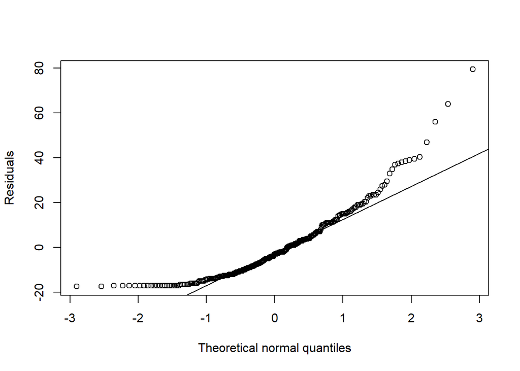

```r
qqnorm(resid(alc_mod1), main="", ylab = "Residuals", xlab = "Theoretical normal quantiles")
qqline(resid(alc_mod1))
```

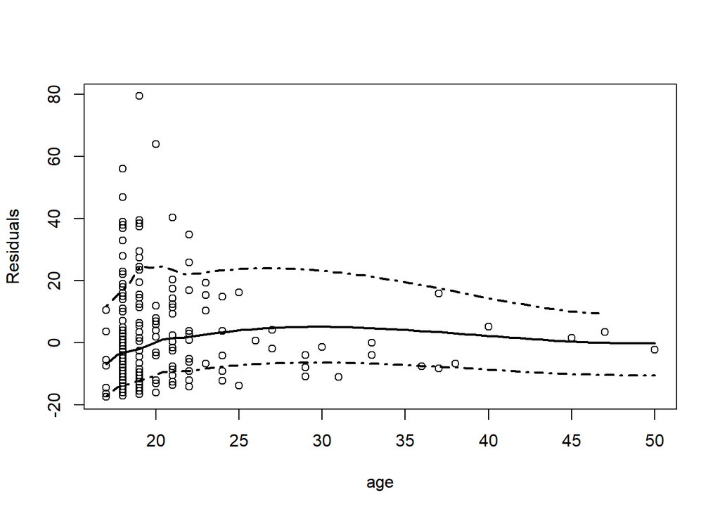

```r
#The distribution of residuals is strongly non-normal.

library(car)
scatterplot(resid(alc_mod1) ~ alcdat$age, boxplot=F, smooth=list(var=T, style="lines",
            lty.smooth=1), regLine=F, data=movie, col="black", grid=F,
            xlab="age", ylab="Residuals")
```

```r
#The scatterplot of residuals by age shows a slight nonlinear trend
#and slightly heterogeneous variance.
```

### *P*-regressor multiple regression: Model estimation

#### Model 2: Four Regressors

```r
#Specify model with 4 regressors
alc_mod2 <- lm(alcohol ~ age + BIS + NEOc + NEOo, data = alcdat)
#Obtain model output
summary(alc_mod2)
```

```
Call:
lm(formula = alcohol ~ age + BIS + NEOc + NEOo, data = alcdat)

Residuals:
    Min      1Q  Median      3Q     Max
-31.271  -9.241  -2.245   7.050  67.776

Coefficients:
            Estimate Std. Error t value Pr(>|t|)
(Intercept) -11.5762    14.6805  -0.789   0.4311
age          -0.3036     0.1830  -1.659   0.0983 .
BIS          16.0065     3.1701   5.049 8.26e-07 ***
NEOc         -2.0075     1.8620  -1.078   0.2820
NEOo          1.2953     1.7691   0.732   0.4647
---
Signif. codes:  0 '***' 0.001 '**' 0.01 '*' 0.05 '.' 0.1 ' ' 1

Residual standard error: 14.51 on 265 degrees of freedom
Multiple R-squared:  0.1769,    Adjusted R-squared:  0.1644
F-statistic: 14.23 on 4 and 265 DF,  p-value: 1.541e-10
```

```r
#For the purpose of hierarchical regression, note that this model produces R^2 = .1769

#Obtain 95% Confidence Intervals
confint(alc_mod2)
```

```
                  2.5 %      97.5 %
(Intercept) -40.4815126 17.32916882
age          -0.6638965  0.05675713
BIS           9.7646751 22.24838125
NEOc         -5.6737293  1.65875501
NEOo         -2.1879608  4.77848042
```

### **Model Comparison: Hierarchical regression**

We can test whether the addition of the personality regressors significantly increase the R^2 over and above the age variable by using the `anova()` function to compare Model 1 with Model 2.

```r
#F-test comparing model 1 and model 2
anova(alc_mod1, alc_mod2)
```

```
Analysis of Variance Table

Model 1: alcohol ~ age
Model 2: alcohol ~ age + BIS + NEOc + NEOo
  Res.Df   RSS Df Sum of Sq    F    Pr(>F)
1    268 66348
2    265 55799  3     10549 16.7 5.745e-10 ***
---
Signif. codes:  0 '***' 0.001 '**' 0.01 '*' 0.05 '.' 0.1 ' ' 1
```

```r
#R^2 for model 2 (.1769) is significantly greater
#than R^2 for model 1 (.02124)
```

## Linearity and constant variance

### Figure 2.3 R Code - Examining Multiple Regression Residuals

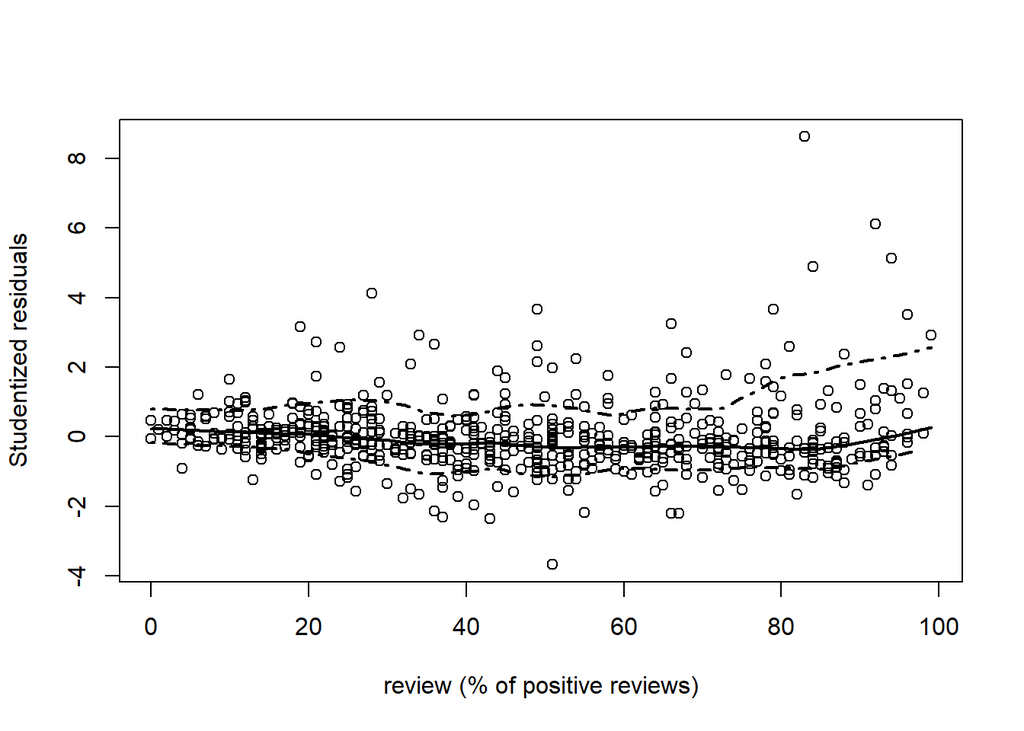

```r
#Studentized residuals can be specified by passing the model through the "rstudent" function.

#Studentized residuals against review
scatterplot(rstudent(movieMod2) ~ review, boxplot=F, smooth=list(var=T, span=.2, style="lines",
            lty.smooth=1), regLine=F, data=movie,
            col="black", grid=F, xlab="review (% of positive reviews)",
            ylab="Studentized residuals")
```

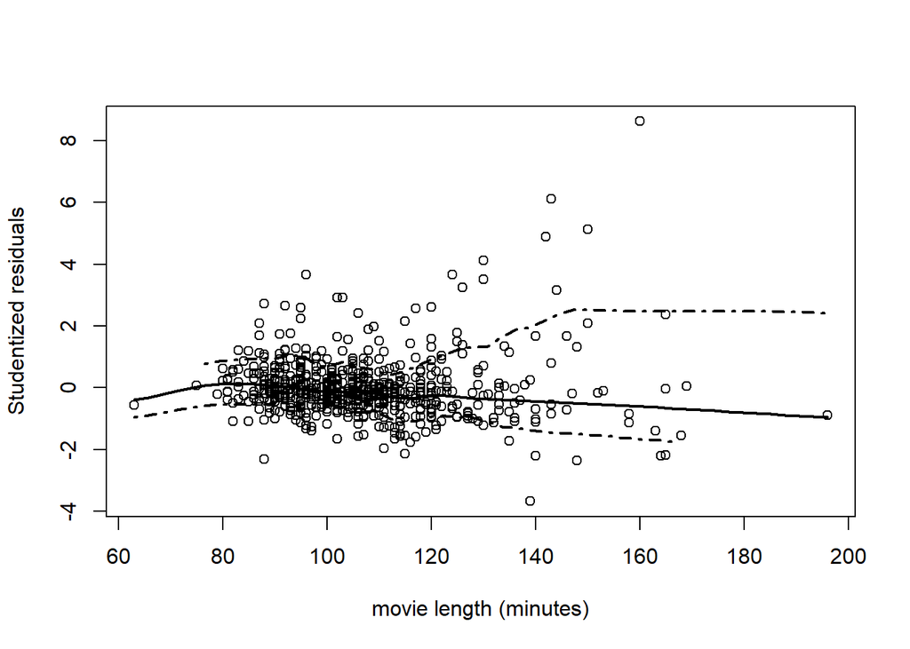

```r
#Studentized residuals against length
scatterplot(rstudent(movieMod2) ~ leng, boxplot=F, smooth=list(var=T, span=.2, style="lines", lty.smooth=1), regLine=F, data=movie,
            col="black", grid=F, xlab="movie length (minutes)",
            ylab="Studentized residuals")
```

### Figure 2.4 R Code - Scatterplot of Studentized residuals against fitted values.

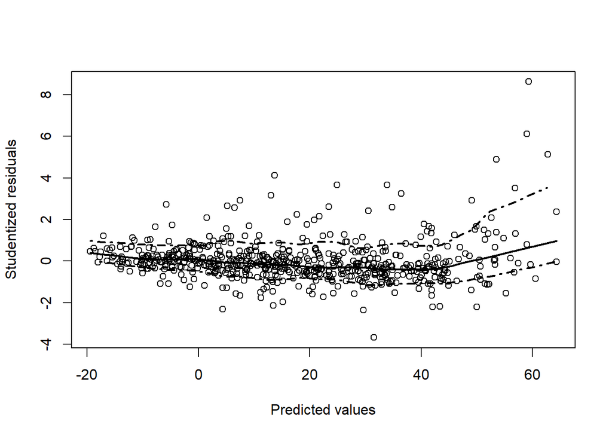

```r
# Fitted values can be obtained by passing the model through the "fitted" function
scatterplot(rstudent(movieMod2) ~ fitted(movieMod2), boxplot=F,smooth=list(var=T, span=.2, style="lines",
                     lty.smooth=1), regLine=F, data=movie,col="black", grid=F, xlab="Predicted values",
                     ylab="Studentized residuals")
```

## Normality

#### Figure 2.5 R Code - QQ Plot of Studentized Residuals

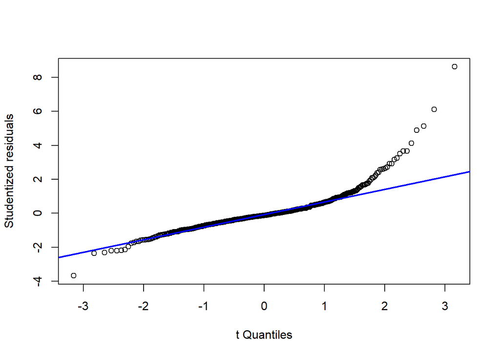

```r
#Plots the Studentized residuals of the model against expected quantiles
#from a t-distribution with df = (N - P - 1)
qqPlot(movieMod2, envelope = F, ylab = "Studentized residuals", grid=F, id=F)
```

## Quadratic Regression

Please see the supplementary text for this Chapter for a conceptual description of quadratic regression.

Here, quadratic regression is demonstrated using the movie example, with review and length as the two explanatory variables. We can specify a new model of movie profit including quadratic terms for both review and length. A quadratic term can be included in the model by enclosing the squared variable expression (e.g., `review^2`) in `I()`. `I()` means “identity,” which indicates that the enclosed expression should be interpreted in their arithmetic sense (as opposed to their symbolic operator usage).

```r
#Specify a quadratic model
quadMod <- lm(profit ~ review + I(review^2) + leng + I(leng^2), data=movie)

#Obtain the model estimates and R^2
summary(quadMod)
```

```
Call:
lm(formula = profit ~ review + I(review^2) + leng + I(leng^2),
    data = movie)

Residuals:
    Min      1Q  Median      3Q     Max
-200.08  -28.47   -6.30   17.79  445.09

Coefficients:
             Estimate Std. Error t value Pr(>|t|)
(Intercept) 51.028837  64.961858   0.786   0.4325
review      -0.965869   0.374893  -2.576   0.0102 *
I(review^2)  0.016180   0.003662   4.418 1.18e-05 ***
leng        -0.972457   1.129535  -0.861   0.3896
I(leng^2)    0.005925   0.004782   1.239   0.2158
---
Signif. codes:  0 '***' 0.001 '**' 0.01 '*' 0.05 '.' 0.1 ' ' 1

Residual standard error: 56.59 on 604 degrees of freedom
Multiple R-squared:  0.131, Adjusted R-squared:  0.1253
F-statistic: 22.77 on 4 and 604 DF,  p-value: < 2.2e-16
```

```r
#Notice that the quadratic estimate for review is statistically significant,
#implying that the (population) association between review and profit is nonlinear.
#See the supplementary text for further explanation.
```

The `anova()` function can be used to compare this model with the original linear model (this is another example of hierarchical regression). These two models can be compared in this way because they are nested (i.e., the more complex model contains all of the terms of the simpler model with one or more additional parameters).

```r
anova(movieMod2,quadMod)
```

```
Analysis of Variance Table

Model 1: profit ~ review + leng
Model 2: profit ~ review + I(review^2) + leng + I(leng^2)
  Res.Df     RSS Df Sum of Sq     F    Pr(>F)
1    606 2005838
2    604 1934295  2     71543 11.17 1.724e-05 ***
---
Signif. codes:  0 '***' 0.001 '**' 0.01 '*' 0.05 '.' 0.1 ' ' 1
```

```r
#The model with quadratic terms fits the data significantly better than the original model.
```

## Investigating Outliers

### Figure 2.6 R Code - Investigating Outliers

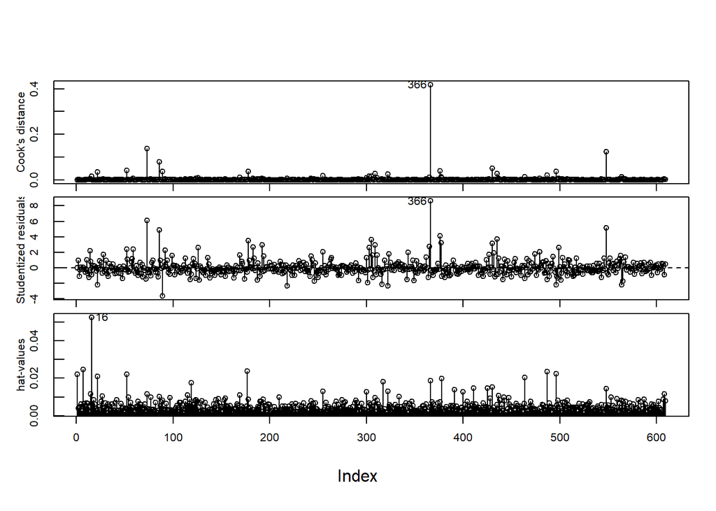

```r
influenceIndexPlot(movieMod2, vars=c("Cook", "Studentized", "hat"), main="", grid=F,
                    id=list(method="y", n=1, cex=1, col=carPalette()[1], location="lr"))
```